# Assignment 6: Visualization - Aesthetic Mapping

*How to do it?*:

- Open the Rmarkdown file of this assignment (link) in Rstudio.
- Right under each **question**, insert a code chunk (you can use the hotkey `Ctrl + Alt + I` to add a code chunk) and code the solution for the question.
- `Knit` the rmarkdown file (hotkey: `Ctrl + Alt + K`) to export an html.
- Publish the html file to your Githiub Page.

*Submission*: Submit the link on Github of the assignment to Canvas.

### Questions on Your Selected Data

Choose a dataset and produce the following types of plots and comment on each plot. Plots should be meaningful. If you use the data we used in class, make sure the plots are not the same as the ones in the slides.

```r
#Using the IMDB Top 1000 dataset listed in Canvas

library(readr)
df <- read_csv('imdb_top_1000.csv')
```

1. For one continuous variable:

```r
library(tidyverse)
library(knitr)
library(lubridate)
```

- Density

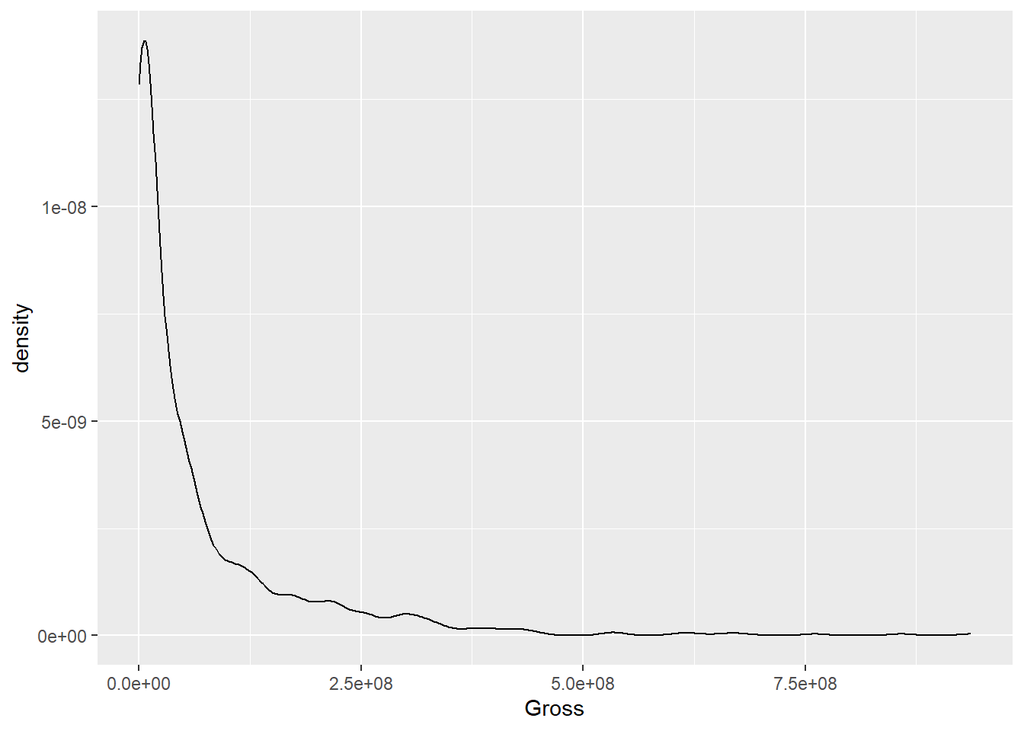

```r
df %>% ggplot()+
  geom_density(mapping = aes(x = Gross))
```

##This density plot above shows that the films’ gross numbers (basically revenue) ##were concentrated at about 1e+08 or below because it is skewed with most ##values towards the left.

- Histogram

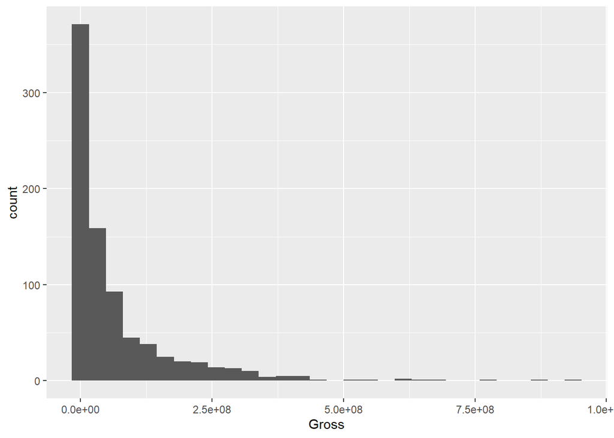

```r
df %>% ggplot()+
  geom_histogram(mapping = aes(x = Gross))
```

##This histogram again shows gross values skewed towards lower values. It is ##notable that the highest bar was at the lowest grossed position.

- Boxplot

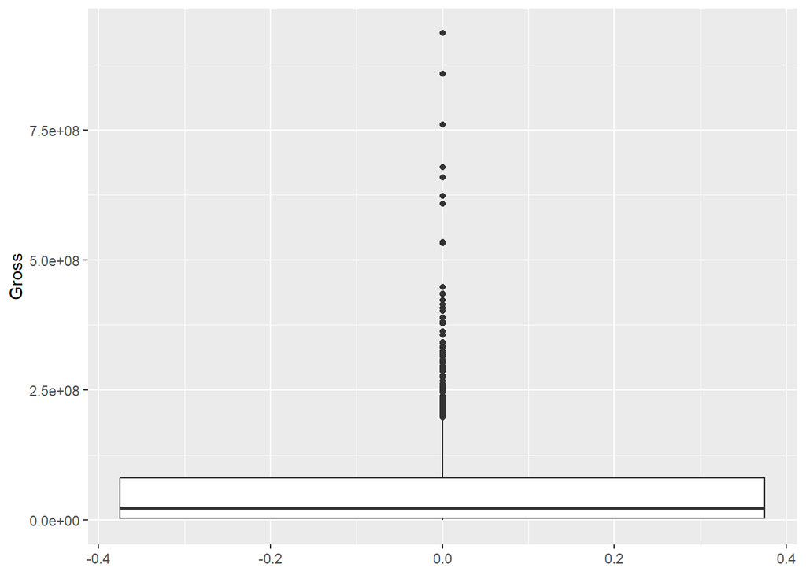

```r
df %>% ggplot()+
  geom_boxplot(mapping = aes(y = Gross))
```

##This boxplot above shows that most values were on the lower end of the gross ##scale. It looks like the bottom 75% of values are at around 1e+08 or lower. ##Some higher outlying points exist.

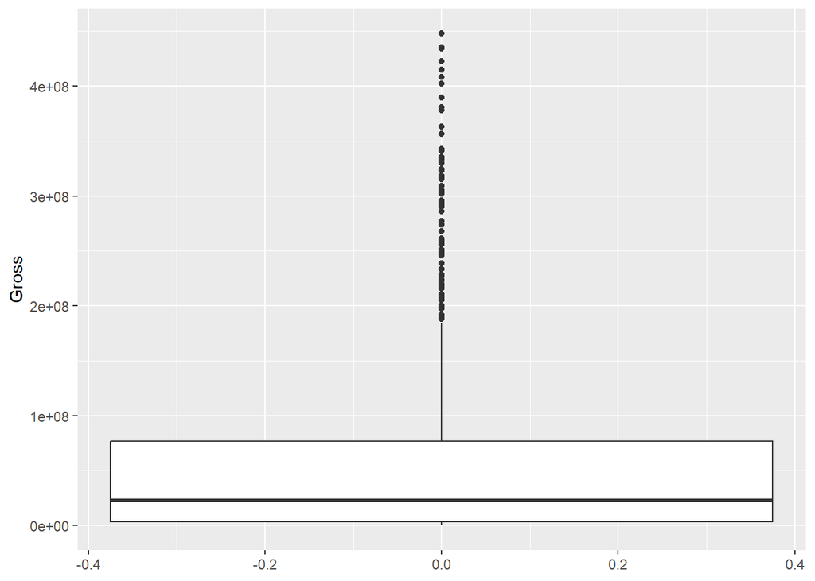

```r
df %>% filter(Gross<500000000) %>% ggplot()+
  geom_boxplot(mapping = aes(y = Gross))
```

##This boxplot uses the same formula as the one before but with a filter added ##to only show the graph up to gross values of 500,000,000. This allows us to ##focus on the more frequent, smaller values. ——-

2. For one categorical variable
- Barplot

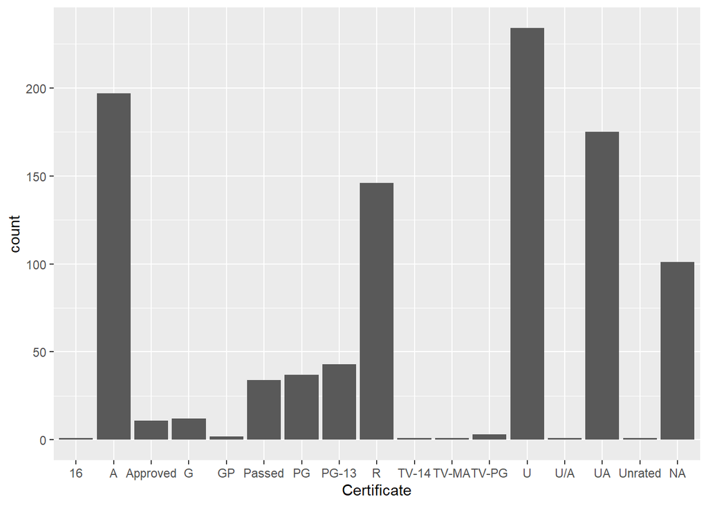

```r
df %>% ggplot()+
  geom_bar(mapping = aes(x = Certificate))
```

##This barplot above shows the frequency of each movie age rating (certificate). ##It is notable that some values, like U and A, are much more frequent than ##others like GP and TV-14.

3. For two continuous variables
- Scatter Plot

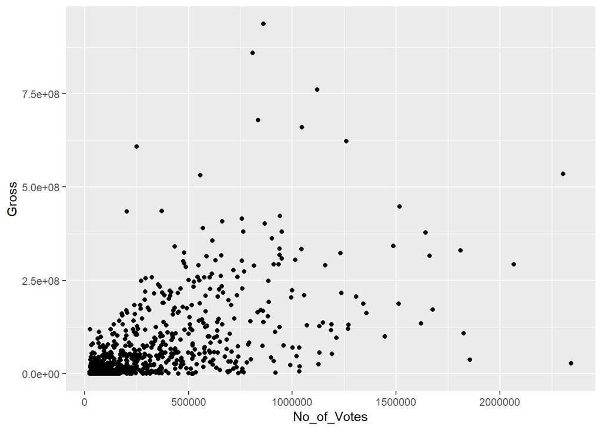

```r
#Scatter Plot: geom_point


df %>% ggplot()+
  geom_point(mapping = aes(x = No_of_Votes,
                           y = Gross))
```

##This scatterplot above shows the relationship between number of votes and ##gross. It looks like it would be hard to intuitively identify a best fit line, ##but again, the data is concentrated around the lower gross values.

- Line Plot

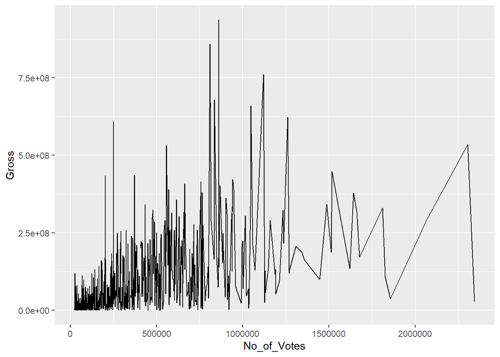

```r
#Line Plot: geom_line

df %>% ggplot()+
  geom_line(mapping = aes(x = No_of_Votes,
                          y = Gross))
```

##This line plot above displays the relationship between adjacent points. This ##is similar to the scatter plot but with the connections between points added. ##This helps to visualize large jumps between adjacent data points, which ##might suggest an element of randomness.

- Smooth Plot

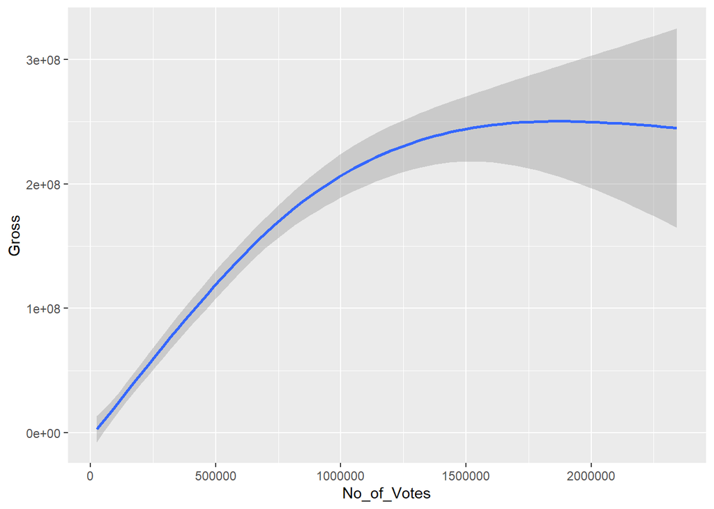

```r
#Smooth Plot: geom_smooth

df %>% ggplot()+
  geom_smooth(mapping = aes(x = No_of_Votes,
                            y = Gross))
```

##This smooth plot shows a best fitted and curved relationship between number ##of votes and gross amount. They appear linearly related up until around ###750,000 votes when the curve becomes more parabolic. ——-

4. For one continuous + one categorical variables
- Density

[output not shown]

[output cut: 209 more lines]

[output not shown]

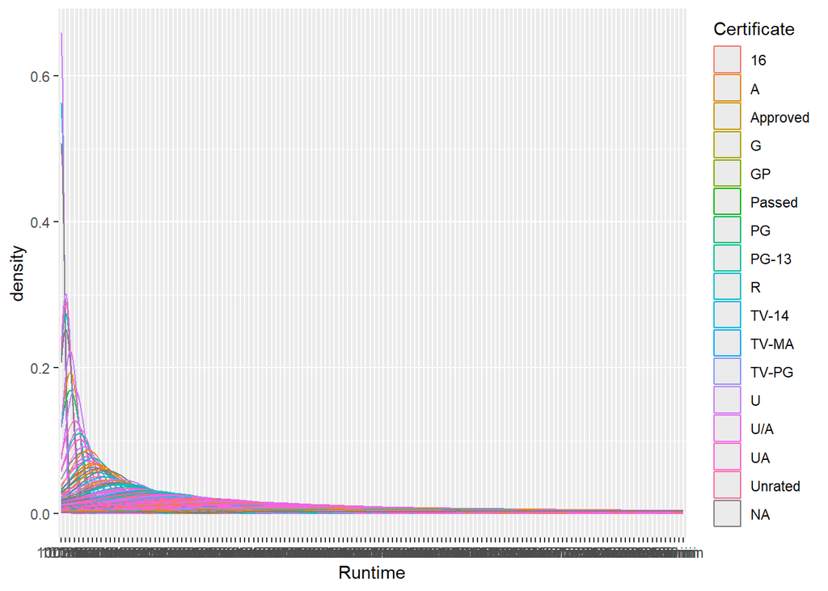

```r
df %>% ggplot()+
  geom_density(mapping = aes(x = Runtime, color = Certificate))
```

##This density plot above displays the density of runtime lengths with the ##added benefit of having colors indicating what the categorical certificate ##rating is. It would probably be better to zoom in on the lower runtime values.

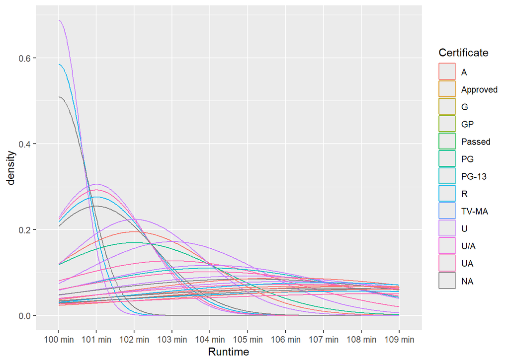

```r
df %>% filter(Runtime<110) %>% ggplot()+
  geom_density(mapping = aes(x = Runtime, color = Certificate))
```

- BoxPlot

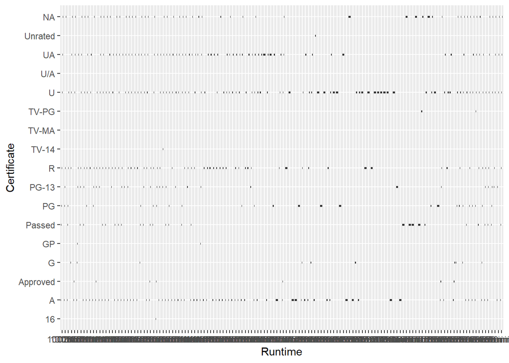

```r
df %>% ggplot()+
  geom_boxplot(mapping = aes(x = Runtime, y = Certificate))
```

##This boxplot above displays how Runtime and Certificate are related. It is ##difficult to interpret this graph because of how small the data points are. ##It would probably be best to filter one or both variables to zoom in.

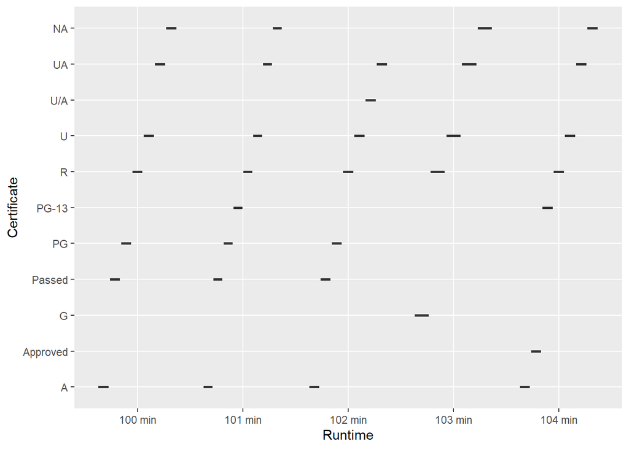

```r
df %>% filter(Runtime<105) %>% ggplot()+
  geom_boxplot(mapping = aes(x = Runtime, y = Certificate))
```

5. For two categorical variables: barplot

[figure not shown]

```r
df %>% ggplot()+
  geom_bar(mapping=aes(x=Certificate, fill=Genre), position = 'fill')
```

##This barplot shows the distribution of Genre and Certificate as they relate ##to each other. Unfortunately this dataset only had categorical variables ##with many possibilities, so this graph contains too much data for the ##available space to really understand the overall trend. It appears that a lot ##of the data is missing from the screen frame.

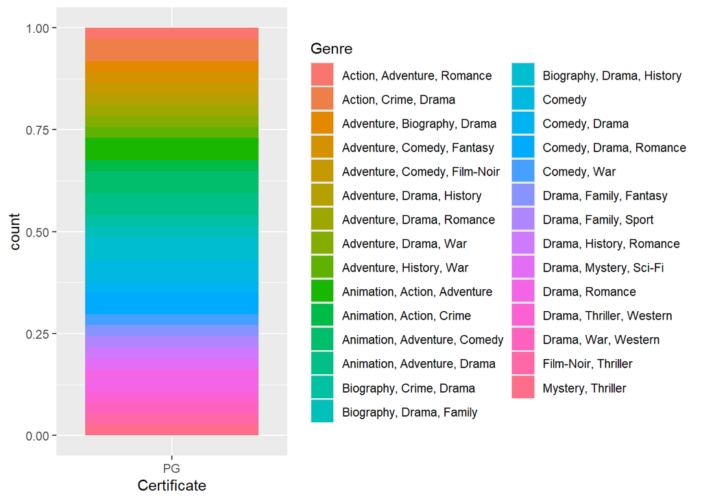

```r
df %>% filter(Certificate=='PG') %>% ggplot()+
  geom_bar(mapping=aes(x=Certificate, fill=Genre), position = 'fill')
```

##This barplot is much easier to interpret than the one before it. By filtering ##the data to just analyze movies with a PG rating, it is easier to see the ##range of genres. This output also includes a graph. As one might expect for a ##PG genre, there are a lot of adventure movies. It would be interesting to ##further compare typical genres for different film age ratings.

6. A plot that contains three variables

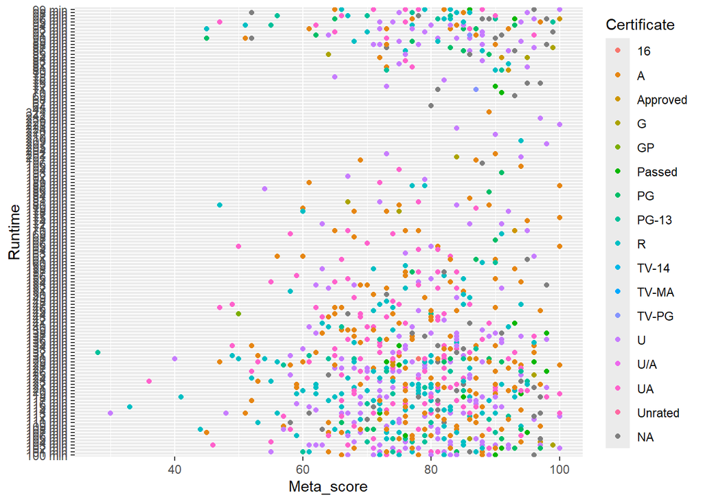

```r
df %>% ggplot() + geom_point(aes(x=Meta_score, y=Runtime, color = Certificate))
```

##This scatterplot displays the relationship between Meta_score and Runtime, ##with a third variable, Certificate, indicating the color of the points. It is ##important to make sure the categorical variable is the color in this case, ##with the continuous variables being on the x and y axes.

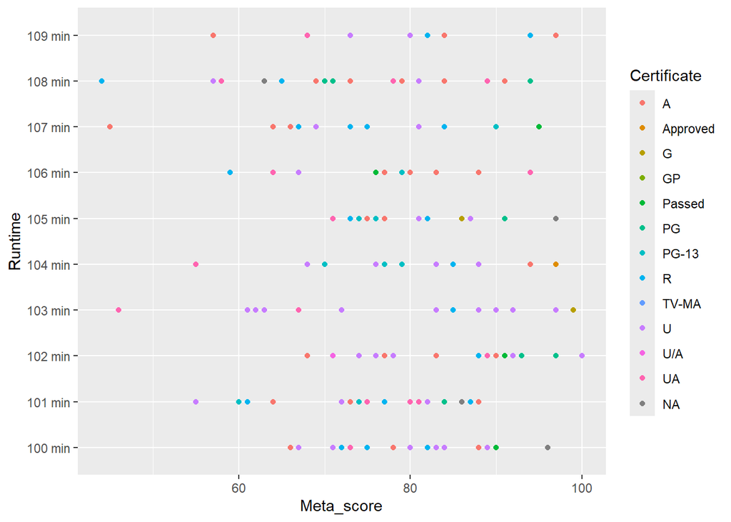

```r
df %>% filter(Runtime<110) %>% ggplot() + geom_point(aes(x=Meta_score, y=Runtime, color = Certificate))
```